# Lab. 8 Dynamic regression models, forecasting example

Análisis y Predicción de Series Temporales, 3º B IMAT

2024-11

# Preliminaries

### Load libraries

```r
library(MLTools)
library(fpp2)
library(ggplot2)
library(tidyverse)
library(TSA)
library(lmtest)  #contains coeftest function
library(tseries) #contains adf.test function
library(Hmisc) # for computing lagged variables
```

**Set working directory**

```r
try(setwd(dirname(rstudioapi::getActiveDocumentContext()$path)))
```

**Load datasets**

We have received the training and test data in separate files, wherein the test data is limited to the exogenous variables (x variables).

The training data is read as follows:

```r
fdata_TR <- read_csv("https://gist.githubusercontent.com/fsansegundo/4bdccfde57696118164f88a55c7d85ef/raw/4a9cf86f907a61fa47631094a7e84c7ca322d098/macro_econ_TR.csv")
head(fdata_TR)
```

```
## # A tibble: 6 × 5
##    year quarter realgdp realcons realinv
##   <dbl>   <dbl>   <dbl>    <dbl>   <dbl>
## 1  1961       1   2819.    1788.    266.
## 2  1961       2   2872.    1814.    286.
## 3  1961       3   2918.    1823.    310.
## 4  1961       4   2978.    1860.    315.
## 5  1962       1   3031.    1879.    334.
## 6  1962       2   3065.    1902.    331.
```

```r
tail(fdata_TR)
```

```
## # A tibble: 6 × 5
##    year quarter realgdp realcons realinv
##   <dbl>   <dbl>   <dbl>    <dbl>   <dbl>
## 1  2008       2  13415.    9351    2027.
## 2  2008       3  13325.    9268.   1991.
## 3  2008       4  13142.    9195.   1858.
## 4  2009       1  12925.    9209.   1558.
## 5  2009       2  12902.    9189    1457.
## 6  2009       3  12990.    9256    1486.
```

and similarly for the test data

```r
fdata_TS <- read_csv("https://gist.githubusercontent.com/fsansegundo/4bdccfde57696118164f88a55c7d85ef/raw/4a9cf86f907a61fa47631094a7e84c7ca322d098/macro_econ_TS.csv")
head(fdata_TS)
```

```
## # A tibble: 6 × 4
##    year quarter realcons realinv
##   <dbl>   <dbl>    <dbl>   <dbl>
## 1  2007       4    9364.   2123.
## 2  2008       1    9350.   2083.
## 3  2008       2    9351    2027.
## 4  2008       3    9268.   1991.
## 5  2008       4    9195.   1858.
## 6  2009       1    9209.   1558.
```

After inspecting the data to examine the date information we remove the corresponding columns from both datasets:

The training data

```r
fdata_TR <- fdata_TR[,-(1:2)]
head(fdata_TR)
```

```
## # A tibble: 6 × 3
##   realgdp realcons realinv
##     <dbl>    <dbl>   <dbl>
## 1   2819.    1788.    266.
## 2   2872.    1814.    286.
## 3   2918.    1823.    310.
## 4   2978.    1860.    315.
## 5   3031.    1879.    334.
## 6   3065.    1902.    331.
```

and the test data

```r
fdata_TS <- fdata_TS[,-(1:2)]
```

And we use that information to convert the training data to time series objects, starting with the frequency

```r
freq <- 4
```

Make sure that the start value is correct here

```r
fdata_ts <- ts(fdata_TR, start = c(1959, 1), frequency = freq)
```

And let us plot the training time series (input and output)

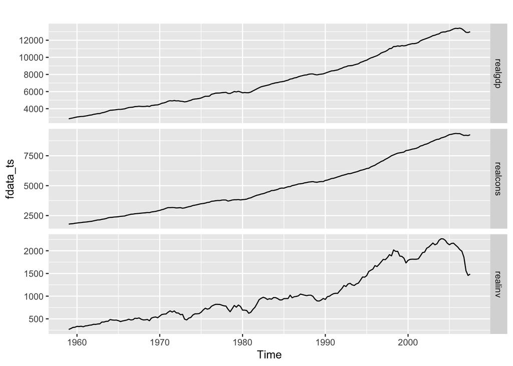

```r
autoplot(fdata_ts, facets = TRUE)
```

If scaling is needed we apply it here

```r
fdata_ts[,1] <- fdata_ts[,1] / 1000
fdata_ts[,2] <- fdata_ts[,2] / 1000
fdata_ts[,3] <- fdata_ts[,3] / 1000
```

Here we need to identify the column corresponding to the output variable y and the columns(s) for the output variable(s) x

```r
x.tr <- fdata_ts[,2:3]
y.tr <- fdata_ts[,1]
```

Let us examine graphically all these time series

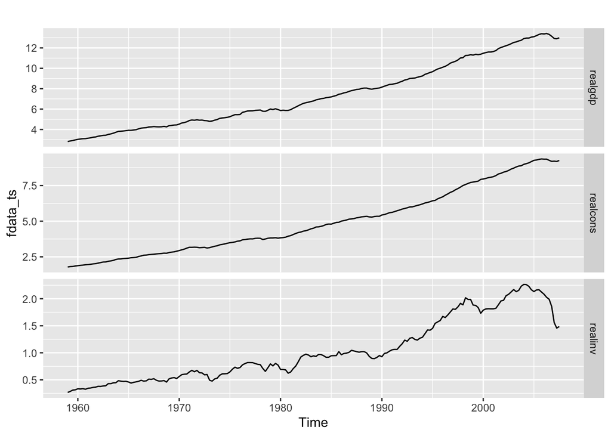

```r
autoplot(fdata_ts, facets = TRUE)
```

In the above plot we look for trend and seasonality. To further explore this we can examine the ACF of the y series

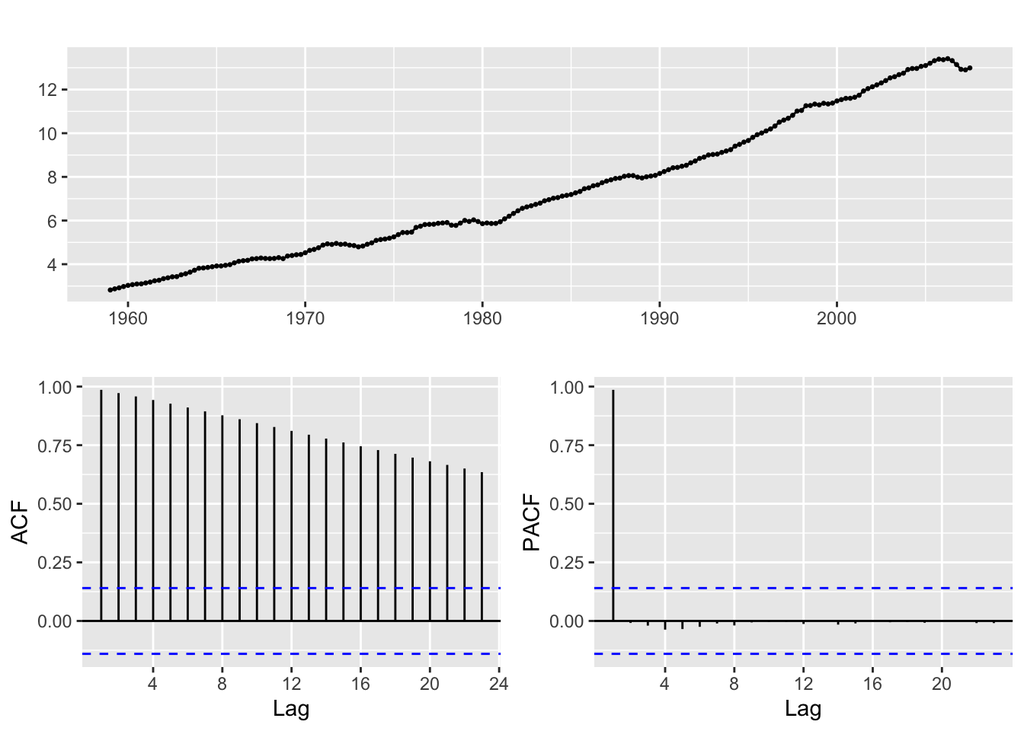

```r
ggtsdisplay(y.tr)
```

In this example there does not appear to be seasonality (in fact, the original data is seasonally adjusted, [see here](https://www.statsmodels.org/dev/datasets/generated/macrodata.html)) but the trend is obvious, so we apply a regular diference

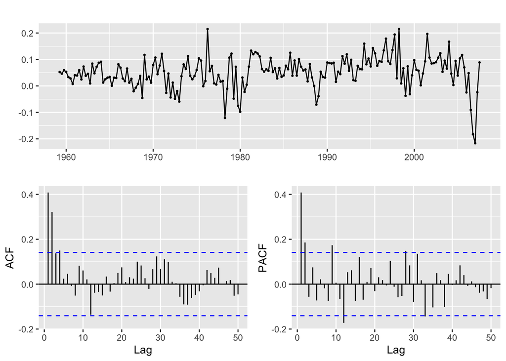

```r
ggtsdisplay(diff(y.tr, lag = 1, differences = 1), lag.max = 50)
```

If you examine the above plot yoou will notice that the regularly differenced time series still seems to have a moderate upward trend. So we decided to apply a second regular difference.

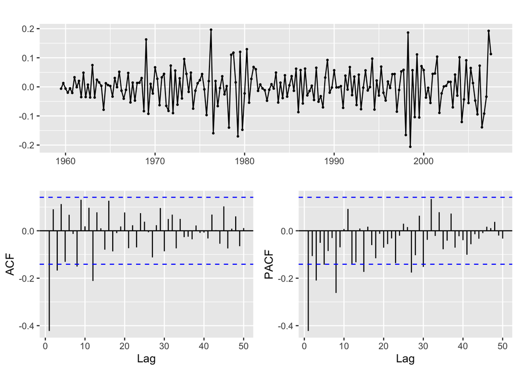

```r
ggtsdisplay(diff(y.tr, lag = 1, differences = 2), lag.max = 50)
```

So we set the regular difference order d (the seasonal difference order D is commented as it is not needed in this example):

```r
d <-  2
# D <- 0
```

Now the series seems stationary and we proceed to identify and fit a TF model.

# Identification and fitting process

#### Fit initial FT model with large s

Note that we use `c(0,9), c(0,9)` in the transfer argument below because we have two input variables. We do not need the seasonal part of the model, but we need to apply the differences we have selected before.

```r
TF.fit <- arima(y.tr,
                order=c(1, d, 0),
                #seasonal = list(order=c(1,D,0), period=freq),
                xtransf = x.tr,
                transfer = list(c(0,9), c(0,9)), #List with (r,s) orders
                include.mean = TRUE,
                method="ML")
summary(TF.fit)
```

```
##
## Call:
## arima(x = y.tr, order = c(1, d, 0), include.mean = TRUE, method = "ML", xtransf = x.tr,
##     transfer = list(c(0, 9), c(0, 9)))
##
## Coefficients:
##           ar1  realcons-MA0  realcons-MA1  realcons-MA2  realcons-MA3
##       -0.5801        1.0343        0.0158        0.1063        0.0630
## s.e.   0.0639        0.0678        0.0798        0.0894        0.0924
##       realcons-MA4  realcons-MA5  realcons-MA6  realcons-MA7  realcons-MA8
##             0.0178        0.1101        0.1645        0.0417        0.0830
## s.e.        0.0980        0.0980        0.0955        0.0964        0.0868
##       realcons-MA9  realinv-MA0  realinv-MA1  realinv-MA2  realinv-MA3
##             0.0828       0.9672      -0.1307      -0.0378      -0.0438
## s.e.        0.0847       0.0571       0.0604       0.0680       0.0716
##       realinv-MA4  realinv-MA5  realinv-MA6  realinv-MA7  realinv-MA8
##           -0.0333      -0.0895      -0.0431      -0.0104      -0.0311
## s.e.       0.0728       0.0724       0.0694       0.0675       0.0624
##       realinv-MA9
##           -0.0331
## s.e.       0.0555
##
## sigma^2 estimated as 0.0006852:  log likelihood = 405.32,  aic = -768.63
##
## Training set error measures:
##                         ME       RMSE       MAE          MPE      MAPE
## Training set -0.0001903929 0.02603549 0.0200261 -0.006269868 0.2774689
##                   MASE       ACF1
## Training set 0.3012988 -0.2113274
```

### Check the statistical significance of estimated coefficients

```r
coeftest(TF.fit)
```

```
##
## z test of coefficients:
##
##               Estimate Std. Error z value Pr(>|z|)
## ar1          -0.580056   0.063886 -9.0796  < 2e-16 ***
## realcons-MA0  1.034275   0.067804 15.2538  < 2e-16 ***
## realcons-MA1  0.015782   0.079825  0.1977  0.84327
## realcons-MA2  0.106342   0.089433  1.1891  0.23441
## realcons-MA3  0.063027   0.092425  0.6819  0.49529
## realcons-MA4  0.017777   0.098029  0.1813  0.85610
## realcons-MA5  0.110129   0.098001  1.1237  0.26112
## realcons-MA6  0.164474   0.095517  1.7219  0.08508 .
## realcons-MA7  0.041687   0.096437  0.4323  0.66554
## realcons-MA8  0.083044   0.086786  0.9569  0.33863
## realcons-MA9  0.082799   0.084671  0.9779  0.32813
## realinv-MA0   0.967195   0.057125 16.9312  < 2e-16 ***
## realinv-MA1  -0.130722   0.060421 -2.1635  0.03050 *
## realinv-MA2  -0.037791   0.067995 -0.5558  0.57835
## realinv-MA3  -0.043846   0.071624 -0.6122  0.54043
## realinv-MA4  -0.033321   0.072835 -0.4575  0.64733
## realinv-MA5  -0.089453   0.072381 -1.2359  0.21651
## realinv-MA6  -0.043064   0.069389 -0.6206  0.53485
## realinv-MA7  -0.010416   0.067521 -0.1543  0.87740
## realinv-MA8  -0.031070   0.062438 -0.4976  0.61875
## realinv-MA9  -0.033147   0.055534 -0.5969  0.55059
## ---
## Signif. codes:  0 '***' 0.001 '**' 0.01 '*' 0.05 '.' 0.1 ' ' 1
```

### Check regression error

The plot below is used to decide about the order of the model for the ARIMA noise

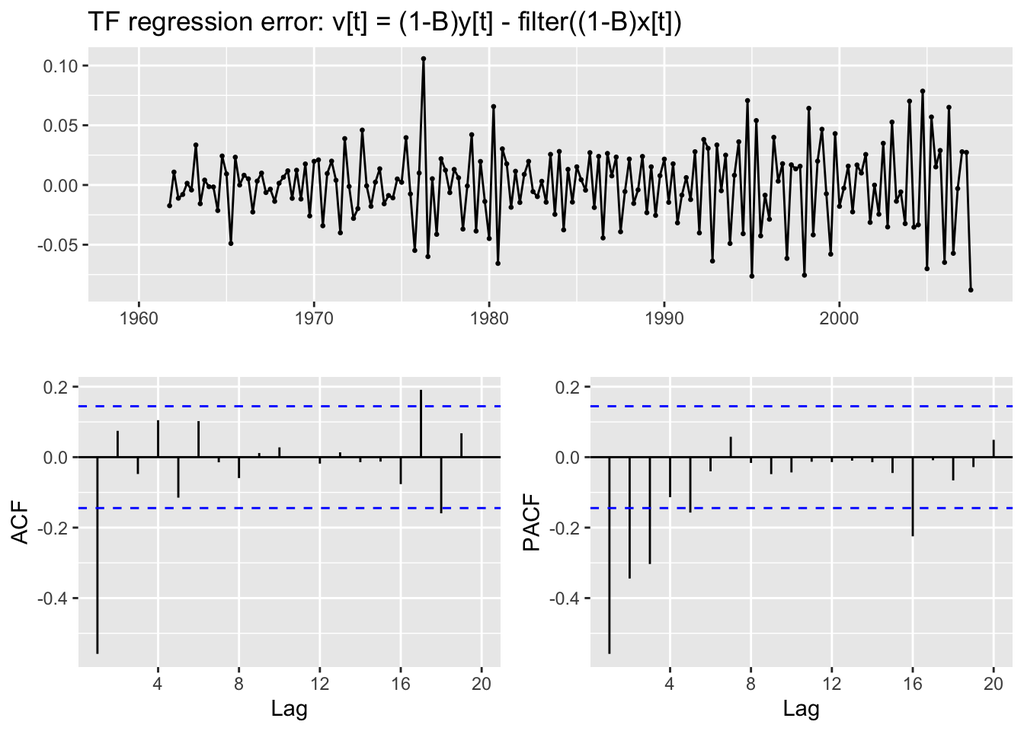

```r
TF.RegressionError.plot(y.tr, x.tr, TF.fit,lag.max = 20)
```

In this particular example we propose this structure (the seasonal order is commented as it is not needed in this example):

```r
p <- 0
q <- 1
# P <- 0
# Q <- 0
```

### Transfer function identification

And this plot (or plots) is used to decide about the values of (b, r, s) in the transfer function(s) for the input variable(s)

```
## [1] "realcons"
##                Estimate Std. Error    z value     Pr(>|z|)
## realcons-MA0 1.03427508 0.06780422 15.2538449 1.552176e-52
## realcons-MA1 0.01578201 0.07982526  0.1977070 8.432743e-01
## realcons-MA2 0.10634186 0.08943293  1.1890683 2.344128e-01
## realcons-MA3 0.06302693 0.09242495  0.6819254 4.952861e-01
## realcons-MA4 0.01777723 0.09802929  0.1813461 8.560959e-01
## realcons-MA5 0.11012856 0.09800108  1.1237485 2.611198e-01
## realcons-MA6 0.16447387 0.09551700  1.7219329 8.508168e-02
## realcons-MA7 0.04168675 0.09643655  0.4322712 6.655443e-01
## realcons-MA8 0.08304383 0.08678594  0.9568812 3.386272e-01
## realcons-MA9 0.08279859 0.08467111  0.9778848 3.281313e-01
## [1] "realinv"
##                Estimate Std. Error    z value     Pr(>|z|)
## realinv-MA0  0.96719536 0.05712488 16.9312454 2.647196e-64
## realinv-MA1 -0.13072244 0.06042115 -2.1635213 3.050110e-02
## realinv-MA2 -0.03779088 0.06799490 -0.5557899 5.783545e-01
## realinv-MA3 -0.04384595 0.07162384 -0.6121698 5.404254e-01
## realinv-MA4 -0.03332069 0.07283525 -0.4574803 6.473259e-01
## realinv-MA5 -0.08945256 0.07238088 -1.2358589 2.165110e-01
## realinv-MA6 -0.04306403 0.06938874 -0.6206198 5.348498e-01
## realinv-MA7 -0.01041576 0.06752063 -0.1542604 8.774044e-01
## realinv-MA8 -0.03107016 0.06243761 -0.4976193 6.187524e-01
## realinv-MA9 -0.03314691 0.05553362 -0.5968800 5.505875e-01
```

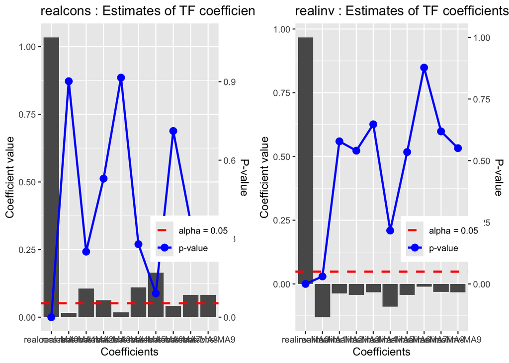

```r
TF.Identification.plot(x.tr,TF.fit)
```

For this example we propose

```r
# First input variable
b1 <- 0
r1 <- 0
s1 <- 0
# Second input variable
b2 <- 0
r2 <- 0
s2 <- 0
```

# Fit transfer function model with the selected parameters

### Lagged input variables

To apply possibly different lags to each input variable we make a copy of the input variables time series and apply the lags sequentially to each column

```r
xlag <- x.tr

xlag[ ,1]  <-  Lag(xlag[ ,1], b1)
xlag[ ,2]  <-  Lag(xlag[ ,2], b2)
```

Next we fill the missing lagged data with 0s

```r
xlag[is.na(xlag)] <-  0
head(xlag)
```

```
##         realcons  realinv
## 1959 Q1   1.7877 0.266405
## 1959 Q2   1.8143 0.286246
## 1959 Q3   1.8231 0.310227
## 1959 Q4   1.8596 0.315463
## 1960 Q1   1.8794 0.334271
## 1960 Q2   1.9025 0.331039
```

### Fit of the model

```r
arima.fit <- arima(y.tr,
                   order=c(p, d, q),
                   #seasonal = list(order=c(P, D, Q),period=freq),
                   xtransf = xlag,
                   transfer = list(c(r1, s1), c(r2, s2)), #List with (r,s) orders
                   include.mean = FALSE,
                   method="ML")

summary(arima.fit)
```

```
##
## Call:
## arima(x = y.tr, order = c(p, d, q), include.mean = FALSE, method = "ML", xtransf = xlag,
##     transfer = list(c(r1, s1), c(r2, s2)))
##
## Coefficients:
##           ma1  realcons-MA0  realinv-MA0
##       -0.8697        0.9198       0.9371
## s.e.   0.0478        0.0603       0.0414
##
## sigma^2 estimated as 0.0005479:  log likelihood = 450.09,  aic = -894.18
##
## Training set error measures:
##                       ME      RMSE        MAE         MPE      MAPE      MASE
## Training set 0.000931879 0.0232878 0.01761074 0.002326141 0.2476114 0.2649589
##                    ACF1
## Training set -0.1363673
```

### Check the statistical significance of estimated coefficients

```r
coeftest(arima.fit)
```

```
##
## z test of coefficients:
##
##               Estimate Std. Error z value  Pr(>|z|)
## ma1          -0.869665   0.047833 -18.181 < 2.2e-16 ***
## realcons-MA0  0.919766   0.060312  15.250 < 2.2e-16 ***
## realinv-MA0   0.937137   0.041367  22.654 < 2.2e-16 ***
## ---
## Signif. codes:  0 '***' 0.001 '**' 0.01 '*' 0.05 '.' 0.1 ' ' 1
```

In this example they are all significant ### Check the residuals

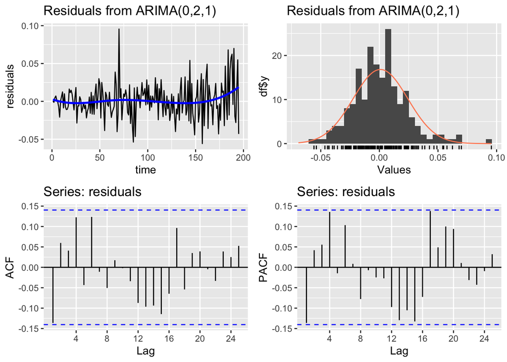

```
##
##  Ljung-Box test
##
## data:  Residuals from ARIMA(0,2,1)
## Q* = 25.809, df = 22, p-value = 0.26
##
## Model df: 3.   Total lags used: 25
```

```r
CheckResiduals.ICAI(arima.fit, lag=25)
```

And the residuals look like gaussian white noise, as confirmed by the Ljung-Box test p-value. ### Cross correlation between residuals and exogenous variable(s)

```r
res <- residuals(arima.fit)
res[is.na(res)] <- 0
```

In examples with more than one exogenous variable we need to examine the cross correlation for each of them

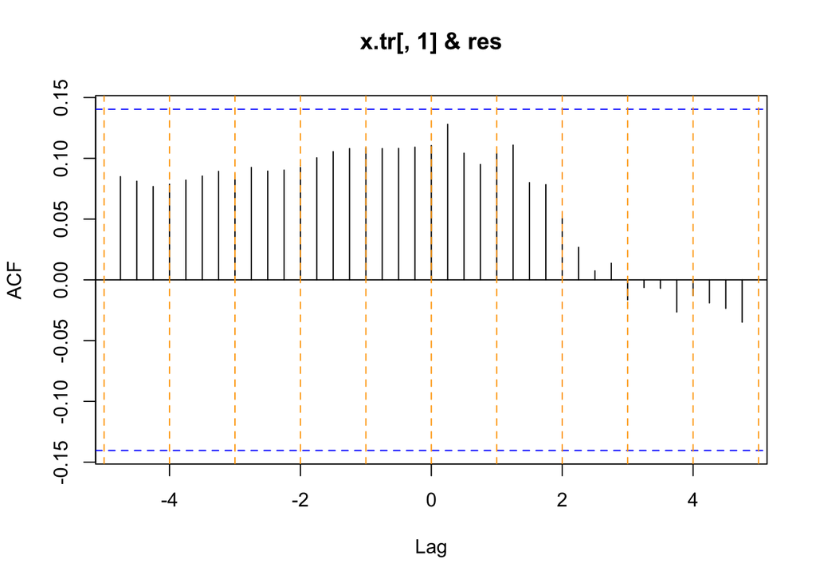

```r
ccf(y = res, x = x.tr[,1])
abline(v = -5:5, col="orange", lty = 2)
```

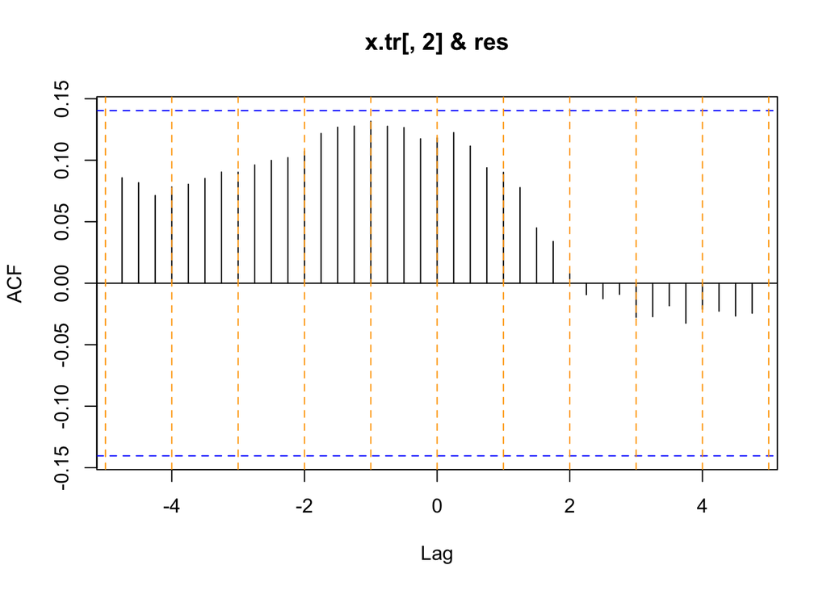

```r
ccf(y = res, x = x.tr[,2])
abline(v = -5:5, col="orange", lty = 2)
```

And in this example we find no significant cross correlation values. ### Graphical check of the fitted values

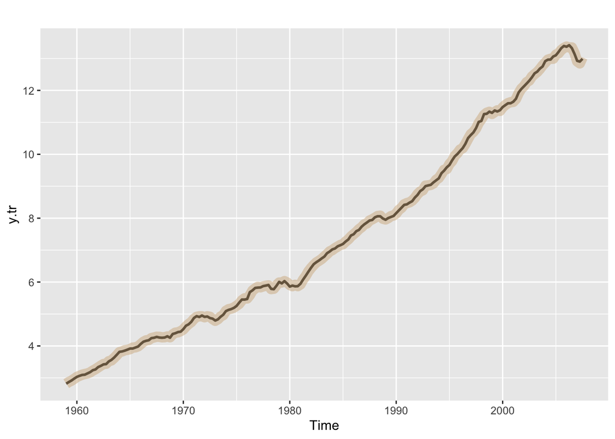

```r
autoplot(y.tr, series = "Real", color="black", size = 1)+
  forecast::autolayer(fitted(arima.fit), series = "Fitted",
                      size = 4, color = "tan", alpha=0.5)
```

### Accuracy in training

```r
accuracy(y.tr, fitted(arima.fit))
```

```
##                    ME      RMSE        MAE          MPE      MAPE       ACF1
## Test set -0.000931879 0.0232878 0.01761074 -0.003345635 0.2476847 -0.1363673
##          Theil's U
## Test set 0.2847447
```

# Forecasting with TF models

In order to perform the forecasting loop (with horizon h = 1) we will create a time series that is a copy of the training output values y.TR but adding extra positions at the end to store the predictions as we generate them (initially they are set to NA) It is created as a vector

```r
y.TS.est <- c(y.tr, rep(NA, nrow(fdata_TS)))
```

But converted as a time series with the same time index as y.TR

```r
y.TS.est <- ts(y.TS.est, start = start(y.tr), frequency = freq)
```

The resulting output data looks like this

```r
head(y.TS.est, 3 * freq)
```

```
##          Qtr1     Qtr2     Qtr3     Qtr4
## 1959 2.819264 2.872005 2.918419 2.977830
## 1960 3.031241 3.064709 3.093047 3.100563
## 1961 3.141087 3.180447 3.240332 3.264967
```

```r
tail(y.TS.est, 3 * freq)
```

```
##          Qtr1     Qtr2     Qtr3     Qtr4
## 2006                            13.14192
## 2007 12.92541 12.90150 12.99034       NA
## 2008       NA       NA       NA       NA
## 2009       NA       NA       NA
```

For the input variables we use rbind (row-bind) to join the training and test data into a single data frame

```r
x.TS.est <- rbind(fdata_TR[, 2:3], fdata_TS)
```

That now is endowed with time series structure

```r
x.TS.est<- ts(x.TS.est, start = c(1959, 1), frequency = freq)
```

If **scaling** was applied in training it is **important** to reapply **the same** here.

```r
x.TS.est[,1] <- x.TS.est[,1] / 1000
x.TS.est[,2] <- x.TS.est[,2] / 1000
```

The resulting input data looks like this

```r
head(x.TS.est)
```

```
##         realcons  realinv
## 1959 Q1   1.7877 0.266405
## 1959 Q2   1.8143 0.286246
## 1959 Q3   1.8231 0.310227
## 1959 Q4   1.8596 0.315463
## 1960 Q1   1.8794 0.334271
## 1960 Q2   1.9025 0.331039
```

```r
tail(x.TS.est)
```

```
##         realcons  realinv
## 2008 Q2   9.3510 2.026518
## 2008 Q3   9.2677 1.990693
## 2008 Q4   9.1953 1.857661
## 2009 Q1   9.2092 1.558494
## 2009 Q2   9.1890 1.456678
## 2009 Q3   9.2560 1.486398
```

Now we are ready for the **forecasting loop**. Note that the values are stored in the last positions of y.TS.est as they are generated, and that the y.old and x.old get extended as the loop travels through the test set.

```r
for (i in seq(length(y.tr) + 1, length(y.TS.est), 1)){      # loop for validation period
  y.TS.est[i] <- TF.forecast(y.old = subset(y.TS.est, end=i-1),     # past values of the series
                             x.old = subset(x.TS.est, end=i-1),     # past values of the explanatory variables
                             x.new = subset(x.TS.est, start = i, end=i), # new values of the explanatory variables
                             model = arima.fit,         # fitted transfer function model
                             h=1)               #Forecast horizon
}
```

The predicted values are in the last positions of y.TS.est (as many as test set data rows)

```r
y_TS_pred <- tail(y.TS.est, nrow(fdata_TS))
y_TS_pred
```

```
##          Qtr1     Qtr2     Qtr3     Qtr4
## 2007                            13.72311
## 2008 13.70905 13.69433 13.62096 13.46652
## 2009 13.23576 13.15858 13.28487
```

We save them into a csv file (with no header for the hackaton)

```r
prediction <- data.frame(y_TS_pred)
prediction
```

```
##   y_TS_pred
## 1  13.72311
## 2  13.70905
## 3  13.69433
## 4  13.62096
## 5  13.46652
## 6  13.23576
## 7  13.15858
## 8  13.28487
```

```r
write_csv(prediction, "Lab8_Macroeconomy_Data_Prediction.csv", col_names = FALSE)
```